# Projekt przedmiotu ‘Wielowymiarowa klasyfikacja danych’

Studia podyplomowe ‘Metody Statystycznej Analizy Danych - edycja IX’

Jędrzej Szelc

2024-09-03

# 1. Wstęp

Celem niniejszego projektu jest zbadanie zależności rocznej liczby zgonów w wyniku przedawkowania opiatów w określonych stanach Stanów Zjednoczonych Ameryki (USA) od wybranych wskaźników makroekeonomicznych.

Dla każdego z analizowanych stanów USA, zastosowane zostaną te same wskaźniki (miary) makroekonomiczne o właściwych dla danego stanu lokalnych wartościach.

## 1.1. Dane

W niniejszym projekcie przeanalizowane zostaną następujące dane panelowe:

- zmienną objaśnianą Y stanowi liczba zgonów z ostatnich dwunastu miesięcy (suma ruchoma) w wyniku przedawkowania opiatów dla danego stanu Stanów Zjednoczonych Ameryki, [1]
- zmienne objaśniające X dla każdego stanu są następujące:
  - X1 - wskaźnik bezrobocia wyrażony w procentach, [2,5,8,11,14],
  - X2 - wskaźnik uczestnictwa w rynku pracy wyrażony w procentach, [3,6,9,12,15],
  - X3 - wskaźnik S&P CoreLogic Case-Shiller dla wybranego miasta danego stanu, [4,7,10,13,16],
- analizowane będą dane dla następujących stanów USA:
  - Waszyngton,
  - Kalifornia,
  - Teksas,
  - Floryda,
  - Nowy Jork.

Wszystkie dane mają przedział czasowy od stycznia 2015 do grudnia 2022 roku włącznie, oraz okres jednego miesiąca kalendarzowego.

Dane panelowe są zbalansowane, przez co rozumiemy, iż dla każdego stanu liczba okresów jest taka sama.

Dodatkowo, wszystkie zmienne objaśniajace X zostały wyrównane sezonowo przez dostawcę danych, czyli System Rezerwy Federalnej Stanów Zjednoczonych.

Odnośniki literaturowe znajdują się w sekcji 7.

## 1.2. Konsultacja merytoryczna

W tym miejscu, autor składa podziękowanie Panu Damianowi Kowalskiemu, absolwentowi Uniwersytetu Warszawskiego, za konsultację i wsparcie merytoryczne w dziedzinie statystyki.

## 1.3. Wstępna konfiguracja

Wstępna konfiguracja programu R-Studio, w którym zostaną wykonane obliczenia:

```r
# Biblioteki:
library("readxl")
library(dplyr)
library(ggplot2)
library(gridExtra)
library(corrplot)
library(GGally)
library(caTools)
library(car)
library(tseries)
library(gplots)
library(plm)
library(lmtest)
# install.packages("devtools")
# devtools::install_github('kkashin/panelAR', force = FALSE)
library(panelAR)

# Wyłączanie warningów (ponowne włączenie warn=0):
options(warn=-1)

# Ścieżka katalogu:
string_sciezka_obecnego_katalogu <- getwd()

# Konfiguracja grafiki:
integer_rozmiar_punktow <- 1
string_kolor_linii <- "steelblue"
integer_rozmiar_czcionki <- 10
string_histogram_fill_colour <- "palegreen3"
string_kolor_czerwony_ogolnie_do_grafiki <- "red"
string_kolor_niebieski_ogolnie_do_grafiki <- "steelblue"
string_kolor_horyzontalnej_linii <- "red"
string_kolor_pionowej_linii <- "red"
string_kolor_linii_regresji_LM <- "red"
string_podpis_osi_liczba_dni_od_01011900 = "Liczba dni od 01.01.1900"
string_podpis_osi_Y = "Zmienna Y"
```

# 2. Wstępna analiza danych

W niniejszej części przeprowadzona zostanie wstępna analiza danych (ang. Initial Data Analysis; IDA).

## 2.1. Statystyka danych

```r
### Wczytuję dane w formie kolumn:
string_plik_z_danymi_w_formie_kolumn <- "20240819 - WKD - Dane w formie kolumn.xlsx"
df_raw_data <- read_excel(paste0(string_sciezka_obecnego_katalogu,"/Dane_Wejsciowe/",string_plik_z_danymi_w_formie_kolumn))

## Pre-processing danych kolumnowych:

# Zostaw tylko zakres dat od 01.2015 do 12.2022 włącznie:
df_dane_kolumnowe <- df_raw_data %>%
  filter(Year < 2023)

# Kopia bezpieczeństwa oryginalnych danych - na wszelki wypadek:
df_dane_kolumnowe_wyjsciowe <- df_dane_kolumnowe

# Nazwy kolumn df_dane_kolumnowe:
wektor_nazwy_kolumn_df_dane_kolumnowe <- colnames(df_dane_kolumnowe)

# Wstępna IDA:
# str(df_dane_kolumnowe)
summary(df_dane_kolumnowe)
```

```
##       O.N.           Month            Year        Full_Date
##  Min.   : 1.00   Min.   : 1.00   Min.   :2015   Min.   :2015-01-07 00:00:00
##  1st Qu.:24.75   1st Qu.: 3.75   1st Qu.:2017   1st Qu.:2016-12-30 06:00:00
##  Median :48.50   Median : 6.50   Median :2018   Median :2018-12-22 12:00:00
##  Mean   :48.50   Mean   : 6.50   Mean   :2018   Mean   :2018-12-22 05:00:00
##  3rd Qu.:72.25   3rd Qu.: 9.25   3rd Qu.:2020   3rd Qu.:2020-12-14 18:00:00
##  Max.   :96.00   Max.   :12.00   Max.   :2022   Max.   :2022-12-07 00:00:00
##   Y_Waszyngton  X1_Waszyngton   X2_Waszyngton   X3_Waszyngton    Y_Kalifornia
##  Min.   : 996   Min.   : 3.70   Min.   :62.40   Min.   :173.4   Min.   : 4603
##  1st Qu.:1132   1st Qu.: 4.30   1st Qu.:63.27   1st Qu.:212.3   1st Qu.: 4789
##  Median :1182   Median : 4.65   Median :63.70   Median :250.3   Median : 5504
##  Mean   :1454   Mean   : 5.22   Mean   :63.90   Mean   :262.2   Mean   : 6925
##  3rd Qu.:1739   3rd Qu.: 5.40   3rd Qu.:64.10   3rd Qu.:298.1   3rd Qu.: 9314
##  Max.   :2753   Max.   :16.70   Max.   :66.20   Max.   :401.6   Max.   :11761
##  X1_Kalifornia    X2_Kalifornia  X3_Kalifornia      Y_Teksas
##  Min.   : 3.800   Min.   :59.6   Min.   :200.4   Min.   :2517
##  1st Qu.: 4.300   1st Qu.:61.7   1st Qu.:234.9   1st Qu.:2807
##  Median : 5.150   Median :62.2   Median :265.7   Median :2978
##  Mean   : 5.841   Mean   :61.9   Mean   :272.7   Mean   :3449
##  3rd Qu.: 6.225   3rd Qu.:62.3   3rd Qu.:297.9   3rd Qu.:4179
##  Max.   :16.100   Max.   :63.0   Max.   :383.7   Max.   :5457
##    X1_Teksas        X2_Teksas       X3_Teksas       Y_Floryda
##  Min.   : 3.400   Min.   :60.30   Min.   :145.6   Min.   :2755
##  1st Qu.: 3.875   1st Qu.:63.70   1st Qu.:171.3   1st Qu.:4932
##  Median : 4.400   Median :63.80   Median :189.7   Median :5406
##  Mean   : 4.776   Mean   :63.74   Mean   :200.2   Mean   :5697
##  3rd Qu.: 4.800   3rd Qu.:64.00   3rd Qu.:212.4   3rd Qu.:7594
##  Max.   :12.800   Max.   :64.20   Max.   :302.2   Max.   :8270
##    X1_Floryda       X2_Floryda      X3_Floryda     Y_Nowy_Jork
##  Min.   : 2.800   Min.   :53.80   Min.   :194.5   Min.   :1510
##  1st Qu.: 3.500   1st Qu.:59.08   1st Qu.:221.1   1st Qu.:2119
##  Median : 4.200   Median :59.20   Median :240.9   Median :2289
##  Mean   : 4.690   Mean   :58.93   Mean   :259.1   Mean   :2420
##  3rd Qu.: 5.125   3rd Qu.:59.30   3rd Qu.:272.3   3rd Qu.:2897
##  Max.   :14.200   Max.   :59.70   Max.   :406.2   Max.   :3401
##   X1_Nowy_Jork     X2_Nowy_Jork    X3_Nowy_Jork
##  Min.   : 3.700   Min.   :56.10   Min.   :176.1
##  1st Qu.: 4.100   1st Qu.:60.10   1st Qu.:186.7
##  Median : 4.700   Median :60.60   Median :200.6
##  Mean   : 5.501   Mean   :60.25   Mean   :209.2
##  3rd Qu.: 5.500   3rd Qu.:60.70   3rd Qu.:225.1
##  Max.   :16.700   Max.   :61.00   Max.   :276.2
```

```r
# head(df_dane_kolumnowe)
# tail(df_dane_kolumnowe)

# Pomocnicze rozbicie ramki danych na indywidualne wektory:
wektor_Full_Date <- df_dane_kolumnowe$Full_Date

wektor_Y_Waszyngton <- df_dane_kolumnowe$Y_Waszyngton
wektor_X1_Waszyngton <- df_dane_kolumnowe$X1_Waszyngton
wektor_X2_Waszyngton <- df_dane_kolumnowe$X2_Waszyngton
wektor_X3_Waszyngton <- df_dane_kolumnowe$X3_Waszyngton

wektor_Y_Kalifornia <- df_dane_kolumnowe$Y_Kalifornia
wektor_X1_Kalifornia <- df_dane_kolumnowe$X1_Kalifornia
wektor_X2_Kalifornia <- df_dane_kolumnowe$X2_Kalifornia
wektor_X3_Kalifornia <- df_dane_kolumnowe$X3_Kalifornia

wektor_Y_Teksas <- df_dane_kolumnowe$Y_Teksas
wektor_X1_Teksas <- df_dane_kolumnowe$X1_Teksas
wektor_X2_Teksas <- df_dane_kolumnowe$X2_Teksas
wektor_X3_Teksas <- df_dane_kolumnowe$X3_Teksas

wektor_Y_Floryda <- df_dane_kolumnowe$Y_Floryda
wektor_X1_Floryda <- df_dane_kolumnowe$X1_Floryda
wektor_X2_Floryda <- df_dane_kolumnowe$X2_Floryda
wektor_X3_Floryda <- df_dane_kolumnowe$X3_Floryda

wektor_Y_Nowy_Jork <- df_dane_kolumnowe$Y_Nowy_Jork
wektor_X1_Nowy_Jork <- df_dane_kolumnowe$X1_Nowy_Jork
wektor_X2_Nowy_Jork <- df_dane_kolumnowe$X2_Nowy_Jork
wektor_X3_Nowy_Jork <- df_dane_kolumnowe$X3_Nowy_Jork

### Wczytuję dane w formie panelowej:
string_plik_z_danymi_w_formie_panelowej <- "20240825 - WKD - Dane w formie panelowej.csv"
df_dane_panelowe <-read.csv(paste0(string_sciezka_obecnego_katalogu,"/Dane_Wejsciowe/",string_plik_z_danymi_w_formie_panelowej), sep = ';', dec = '.')

## Pre-processing danych panelowych:
df_dane_panelowe$X1 <- as.numeric(gsub(",", ".", df_dane_panelowe$X1))
df_dane_panelowe$X2 <- as.numeric(gsub(",", ".", df_dane_panelowe$X2))
df_dane_panelowe$X3 <- as.numeric(gsub(",", ".", df_dane_panelowe$X3))
```

## 2.2. Wykresy porównawcze Y

Poniżej przedstawiono wykres porównawczy zmiennych Y przy zachowanej skali osi pionowej.

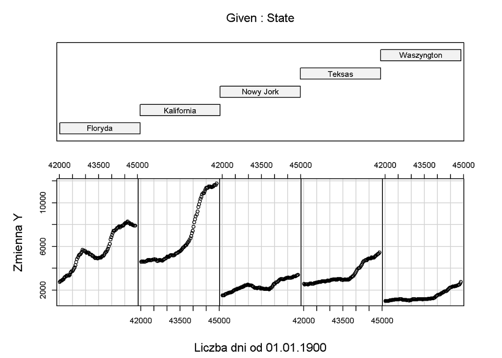

```r
### IDA z wykresami:

# Coplot porównawczy szeregów czasowych zmiennej Y:
coplot(Y ~ Full_Date|State, type="b", data=df_dane_panelowe, rows=1,
       xlab = string_podpis_osi_liczba_dni_od_01011900, ylab = string_podpis_osi_Y,
       show.given = TRUE)
```

Pozniżej przedstawiono wykres złożeniowy zmiennych Y przy zachowanej skali osi pionowej.

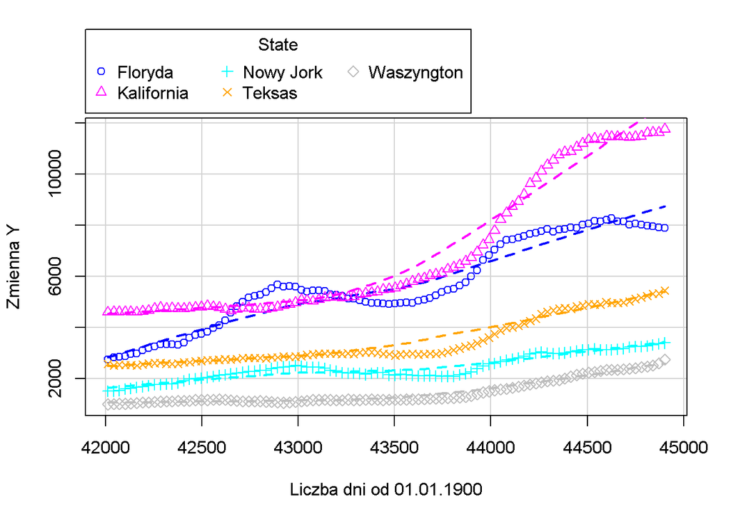

```r
# Scatterplot złożeniowy szeregów czasowych zmiennej Y:
scatterplot(Y ~ Full_Date|State, boxplots=FALSE, smooth=TRUE, regLine=FALSE,
            data=df_dane_panelowe,
            xlab = string_podpis_osi_liczba_dni_od_01011900,
            ylab = string_podpis_osi_Y)
```

## 2.3. Wykresy szeregów czasowych

Poniżej przedstawiono wykresy wszystkich zmiennych w funkcji czasu (szeregi czasowe).

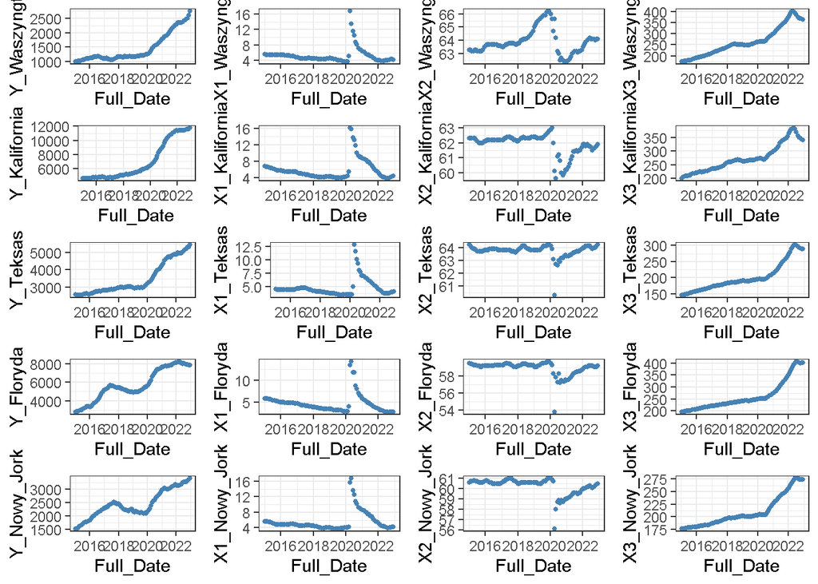

```r
# Wykresy liniowe dla stanu Waszyngton:
obiekt_lineplot_Y_Waszyngton <- ggplot(df_dane_kolumnowe, aes(Full_Date, Y_Waszyngton)) + geom_point(size = integer_rozmiar_punktow, color = string_kolor_linii) + theme(text = element_text(size=integer_rozmiar_czcionki)) + theme_bw()
obiekt_lineplot_X1_Waszyngton <- ggplot(df_dane_kolumnowe, aes(Full_Date, X1_Waszyngton)) + geom_point(size = integer_rozmiar_punktow, color = string_kolor_linii) + theme(text = element_text(size=integer_rozmiar_czcionki)) + theme_bw()
obiekt_lineplot_X2_Waszyngton <- ggplot(df_dane_kolumnowe, aes(Full_Date, X2_Waszyngton)) + geom_point(size = integer_rozmiar_punktow, color = string_kolor_linii) + theme(text = element_text(size=integer_rozmiar_czcionki)) + theme_bw()
obiekt_lineplot_X3_Waszyngton <- ggplot(df_dane_kolumnowe, aes(Full_Date, X3_Waszyngton)) + geom_point(size = integer_rozmiar_punktow, color = string_kolor_linii) + theme(text = element_text(size=integer_rozmiar_czcionki)) + theme_bw()

obiekt_lineplot_Y_Kalifornia <- ggplot(df_dane_kolumnowe, aes(Full_Date, Y_Kalifornia)) + geom_point(size = integer_rozmiar_punktow, color = string_kolor_linii) + theme(text = element_text(size=integer_rozmiar_czcionki)) + theme_bw()
obiekt_lineplot_X1_Kalifornia <- ggplot(df_dane_kolumnowe, aes(Full_Date, X1_Kalifornia)) + geom_point(size = integer_rozmiar_punktow, color = string_kolor_linii) + theme(text = element_text(size=integer_rozmiar_czcionki)) + theme_bw()
obiekt_lineplot_X2_Kalifornia <- ggplot(df_dane_kolumnowe, aes(Full_Date, X2_Kalifornia)) + geom_point(size = integer_rozmiar_punktow, color = string_kolor_linii) + theme(text = element_text(size=integer_rozmiar_czcionki)) + theme_bw()
obiekt_lineplot_X3_Kalifornia <- ggplot(df_dane_kolumnowe, aes(Full_Date, X3_Kalifornia)) + geom_point(size = integer_rozmiar_punktow, color = string_kolor_linii) + theme(text = element_text(size=integer_rozmiar_czcionki)) + theme_bw()

obiekt_lineplot_Y_Teksas <- ggplot(df_dane_kolumnowe, aes(Full_Date, Y_Teksas)) + geom_point(size = integer_rozmiar_punktow, color = string_kolor_linii) + theme(text = element_text(size=integer_rozmiar_czcionki)) + theme_bw()
obiekt_lineplot_X1_Teksas <- ggplot(df_dane_kolumnowe, aes(Full_Date, X1_Teksas)) + geom_point(size = integer_rozmiar_punktow, color = string_kolor_linii) + theme(text = element_text(size=integer_rozmiar_czcionki)) + theme_bw()
obiekt_lineplot_X2_Teksas <- ggplot(df_dane_kolumnowe, aes(Full_Date, X2_Teksas)) + geom_point(size = integer_rozmiar_punktow, color = string_kolor_linii) + theme(text = element_text(size=integer_rozmiar_czcionki)) + theme_bw()
obiekt_lineplot_X3_Teksas <- ggplot(df_dane_kolumnowe, aes(Full_Date, X3_Teksas)) + geom_point(size = integer_rozmiar_punktow, color = string_kolor_linii) + theme(text = element_text(size=integer_rozmiar_czcionki)) + theme_bw()

obiekt_lineplot_Y_Floryda <- ggplot(df_dane_kolumnowe, aes(Full_Date, Y_Floryda)) + geom_point(size = integer_rozmiar_punktow, color = string_kolor_linii) + theme(text = element_text(size=integer_rozmiar_czcionki)) + theme_bw()
obiekt_lineplot_X1_Floryda <- ggplot(df_dane_kolumnowe, aes(Full_Date, X1_Floryda)) + geom_point(size = integer_rozmiar_punktow, color = string_kolor_linii) + theme(text = element_text(size=integer_rozmiar_czcionki)) + theme_bw()
obiekt_lineplot_X2_Floryda <- ggplot(df_dane_kolumnowe, aes(Full_Date, X2_Floryda)) + geom_point(size = integer_rozmiar_punktow, color = string_kolor_linii) + theme(text = element_text(size=integer_rozmiar_czcionki)) + theme_bw()
obiekt_lineplot_X3_Floryda <- ggplot(df_dane_kolumnowe, aes(Full_Date, X3_Floryda)) + geom_point(size = integer_rozmiar_punktow, color = string_kolor_linii) + theme(text = element_text(size=integer_rozmiar_czcionki)) + theme_bw()

obiekt_lineplot_Y_Nowy_Jork <- ggplot(df_dane_kolumnowe, aes(Full_Date, Y_Nowy_Jork)) + geom_point(size = integer_rozmiar_punktow, color = string_kolor_linii) + theme(text = element_text(size=integer_rozmiar_czcionki)) + theme_bw()
obiekt_lineplot_X1_Nowy_Jork <- ggplot(df_dane_kolumnowe, aes(Full_Date, X1_Nowy_Jork)) + geom_point(size = integer_rozmiar_punktow, color = string_kolor_linii) + theme(text = element_text(size=integer_rozmiar_czcionki)) + theme_bw()
obiekt_lineplot_X2_Nowy_Jork <- ggplot(df_dane_kolumnowe, aes(Full_Date, X2_Nowy_Jork)) + geom_point(size = integer_rozmiar_punktow, color = string_kolor_linii) + theme(text = element_text(size=integer_rozmiar_czcionki)) + theme_bw()
obiekt_lineplot_X3_Nowy_Jork <- ggplot(df_dane_kolumnowe, aes(Full_Date, X3_Nowy_Jork)) + geom_point(size = integer_rozmiar_punktow, color = string_kolor_linii) + theme(text = element_text(size=integer_rozmiar_czcionki)) + theme_bw()

lista_obiektow_lineplot <- list(obiekt_lineplot_Y_Waszyngton,
                                obiekt_lineplot_X1_Waszyngton,
                                obiekt_lineplot_X2_Waszyngton,
                                obiekt_lineplot_X3_Waszyngton,
                                obiekt_lineplot_Y_Kalifornia,
                                obiekt_lineplot_X1_Kalifornia,
                                obiekt_lineplot_X2_Kalifornia,
                                obiekt_lineplot_X3_Kalifornia,
                                obiekt_lineplot_Y_Teksas,
                                obiekt_lineplot_X1_Teksas,
                                obiekt_lineplot_X2_Teksas,
                                obiekt_lineplot_X3_Teksas,
                                obiekt_lineplot_Y_Floryda,
                                obiekt_lineplot_X1_Floryda,
                                obiekt_lineplot_X2_Floryda,
                                obiekt_lineplot_X3_Floryda,
                                obiekt_lineplot_Y_Nowy_Jork,
                                obiekt_lineplot_X1_Nowy_Jork,
                                obiekt_lineplot_X2_Nowy_Jork,
                                obiekt_lineplot_X3_Nowy_Jork)

grid.arrange(grobs = lista_obiektow_lineplot, ncol = 4, nrow = 5)
```

## 2.4. Histogramy

Histogramy wszystkich zmiennych znajdują się poniżej.

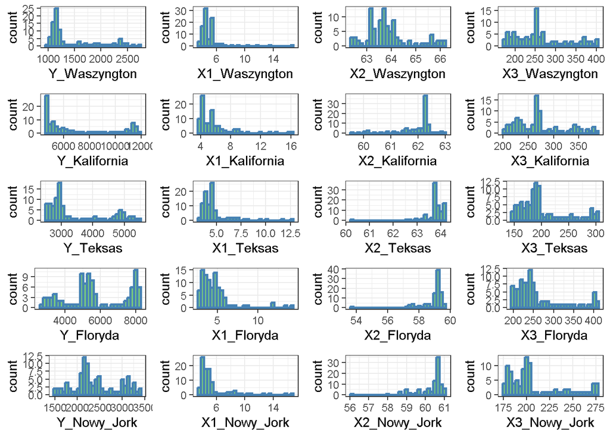

```r
# Histogramy:
obiekt_histogram_Y_Waszyngton <- ggplot(df_dane_kolumnowe, aes(x=Y_Waszyngton)) + geom_histogram(size = integer_rozmiar_punktow, color = string_kolor_linii, fill = string_histogram_fill_colour) + theme(text = element_text(size=integer_rozmiar_czcionki)) + theme_bw()
obiekt_histogram_X1_Waszyngton <- ggplot(df_dane_kolumnowe, aes(x=X1_Waszyngton)) + geom_histogram(size = integer_rozmiar_punktow, color = string_kolor_linii, fill = string_histogram_fill_colour) + theme(text = element_text(size=integer_rozmiar_czcionki)) + theme_bw()
obiekt_histogram_X2_Waszyngton <- ggplot(df_dane_kolumnowe, aes(x=X2_Waszyngton)) + geom_histogram(size = integer_rozmiar_punktow, color = string_kolor_linii, fill = string_histogram_fill_colour) + theme(text = element_text(size=integer_rozmiar_czcionki)) + theme_bw()
obiekt_histogram_X3_Waszyngton <- ggplot(df_dane_kolumnowe, aes(x=X3_Waszyngton)) + geom_histogram(size = integer_rozmiar_punktow, color = string_kolor_linii, fill = string_histogram_fill_colour) + theme(text = element_text(size=integer_rozmiar_czcionki)) + theme_bw()

obiekt_histogram_Y_Kalifornia <- ggplot(df_dane_kolumnowe, aes(x=Y_Kalifornia)) + geom_histogram(size = integer_rozmiar_punktow, color = string_kolor_linii, fill = string_histogram_fill_colour) + theme(text = element_text(size=integer_rozmiar_czcionki)) + theme_bw()
obiekt_histogram_X1_Kalifornia <- ggplot(df_dane_kolumnowe, aes(x=X1_Kalifornia)) + geom_histogram(size = integer_rozmiar_punktow, color = string_kolor_linii, fill = string_histogram_fill_colour) + theme(text = element_text(size=integer_rozmiar_czcionki)) + theme_bw()
obiekt_histogram_X2_Kalifornia <- ggplot(df_dane_kolumnowe, aes(x=X2_Kalifornia)) + geom_histogram(size = integer_rozmiar_punktow, color = string_kolor_linii, fill = string_histogram_fill_colour) + theme(text = element_text(size=integer_rozmiar_czcionki)) + theme_bw()
obiekt_histogram_X3_Kalifornia <- ggplot(df_dane_kolumnowe, aes(x=X3_Kalifornia)) + geom_histogram(size = integer_rozmiar_punktow, color = string_kolor_linii, fill = string_histogram_fill_colour) + theme(text = element_text(size=integer_rozmiar_czcionki)) + theme_bw()

obiekt_histogram_Y_Teksas <- ggplot(df_dane_kolumnowe, aes(x=Y_Teksas)) + geom_histogram(size = integer_rozmiar_punktow, color = string_kolor_linii, fill = string_histogram_fill_colour) + theme(text = element_text(size=integer_rozmiar_czcionki)) + theme_bw()
obiekt_histogram_X1_Teksas <- ggplot(df_dane_kolumnowe, aes(x=X1_Teksas)) + geom_histogram(size = integer_rozmiar_punktow, color = string_kolor_linii, fill = string_histogram_fill_colour) + theme(text = element_text(size=integer_rozmiar_czcionki)) + theme_bw()
obiekt_histogram_X2_Teksas <- ggplot(df_dane_kolumnowe, aes(x=X2_Teksas)) + geom_histogram(size = integer_rozmiar_punktow, color = string_kolor_linii, fill = string_histogram_fill_colour) + theme(text = element_text(size=integer_rozmiar_czcionki)) + theme_bw()
obiekt_histogram_X3_Teksas <- ggplot(df_dane_kolumnowe, aes(x=X3_Teksas)) + geom_histogram(size = integer_rozmiar_punktow, color = string_kolor_linii, fill = string_histogram_fill_colour) + theme(text = element_text(size=integer_rozmiar_czcionki)) + theme_bw()

obiekt_histogram_Y_Floryda <- ggplot(df_dane_kolumnowe, aes(x=Y_Floryda)) + geom_histogram(size = integer_rozmiar_punktow, color = string_kolor_linii, fill = string_histogram_fill_colour) + theme(text = element_text(size=integer_rozmiar_czcionki)) + theme_bw()
obiekt_histogram_X1_Floryda <- ggplot(df_dane_kolumnowe, aes(x=X1_Floryda)) + geom_histogram(size = integer_rozmiar_punktow, color = string_kolor_linii, fill = string_histogram_fill_colour) + theme(text = element_text(size=integer_rozmiar_czcionki)) + theme_bw()
obiekt_histogram_X2_Floryda <- ggplot(df_dane_kolumnowe, aes(x=X2_Floryda)) + geom_histogram(size = integer_rozmiar_punktow, color = string_kolor_linii, fill = string_histogram_fill_colour) + theme(text = element_text(size=integer_rozmiar_czcionki)) + theme_bw()
obiekt_histogram_X3_Floryda <- ggplot(df_dane_kolumnowe, aes(x=X3_Floryda)) + geom_histogram(size = integer_rozmiar_punktow, color = string_kolor_linii, fill = string_histogram_fill_colour) + theme(text = element_text(size=integer_rozmiar_czcionki)) + theme_bw()

obiekt_histogram_Y_Nowy_Jork <- ggplot(df_dane_kolumnowe, aes(x=Y_Nowy_Jork)) + geom_histogram(size = integer_rozmiar_punktow, color = string_kolor_linii, fill = string_histogram_fill_colour) + theme(text = element_text(size=integer_rozmiar_czcionki)) + theme_bw()
obiekt_histogram_X1_Nowy_Jork <- ggplot(df_dane_kolumnowe, aes(x=X1_Nowy_Jork)) + geom_histogram(size = integer_rozmiar_punktow, color = string_kolor_linii, fill = string_histogram_fill_colour) + theme(text = element_text(size=integer_rozmiar_czcionki)) + theme_bw()
obiekt_histogram_X2_Nowy_Jork <- ggplot(df_dane_kolumnowe, aes(x=X2_Nowy_Jork)) + geom_histogram(size = integer_rozmiar_punktow, color = string_kolor_linii, fill = string_histogram_fill_colour) + theme(text = element_text(size=integer_rozmiar_czcionki)) + theme_bw()
obiekt_histogram_X3_Nowy_Jork <- ggplot(df_dane_kolumnowe, aes(x=X3_Nowy_Jork)) + geom_histogram(size = integer_rozmiar_punktow, color = string_kolor_linii, fill = string_histogram_fill_colour) + theme(text = element_text(size=integer_rozmiar_czcionki)) + theme_bw()

lista_obiektow_histogram <- list(obiekt_histogram_Y_Waszyngton,
                                 obiekt_histogram_X1_Waszyngton,
                                 obiekt_histogram_X2_Waszyngton,
                                 obiekt_histogram_X3_Waszyngton,
                                 obiekt_histogram_Y_Kalifornia,
                                 obiekt_histogram_X1_Kalifornia,
                                 obiekt_histogram_X2_Kalifornia,
                                 obiekt_histogram_X3_Kalifornia,
                                 obiekt_histogram_Y_Teksas,
                                 obiekt_histogram_X1_Teksas,
                                 obiekt_histogram_X2_Teksas,
                                 obiekt_histogram_X3_Teksas,
                                 obiekt_histogram_Y_Floryda,
                                 obiekt_histogram_X1_Floryda,
                                 obiekt_histogram_X2_Floryda,
                                 obiekt_histogram_X3_Floryda,
                                 obiekt_histogram_Y_Nowy_Jork,
                                 obiekt_histogram_X1_Nowy_Jork,
                                 obiekt_histogram_X2_Nowy_Jork,
                                 obiekt_histogram_X3_Nowy_Jork)

grid.arrange(grobs = lista_obiektow_histogram, ncol = 4, nrow = 5)
```

## 2.5. Wykresy pudełkowe

Poniżej przedstawiono wykresy pudełkowe wszystkich zmiennych.

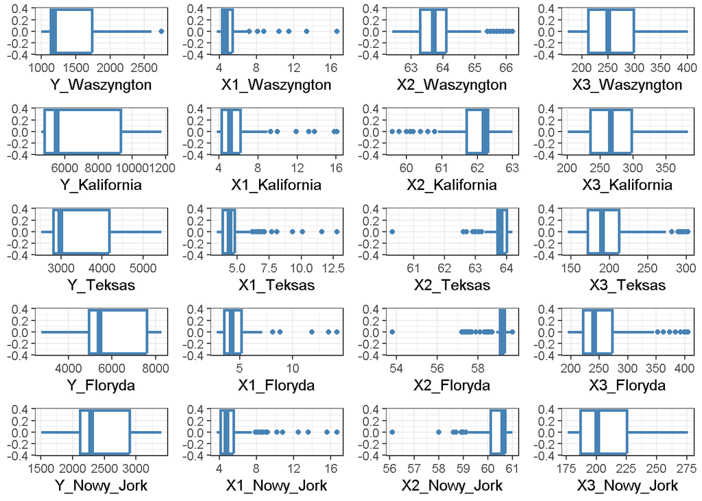

```r
# Wykresy pudełkowe:
obiekt_boxplot_Y_Waszyngton <- ggplot(df_dane_kolumnowe, aes(x=Y_Waszyngton)) + geom_boxplot(size = integer_rozmiar_punktow, color = string_kolor_linii) + theme(text = element_text(size=integer_rozmiar_czcionki)) + theme_bw()
obiekt_boxplot_X1_Waszyngton <- ggplot(df_dane_kolumnowe, aes(x=X1_Waszyngton)) + geom_boxplot(size = integer_rozmiar_punktow, color = string_kolor_linii) + theme(text = element_text(size=integer_rozmiar_czcionki)) + theme_bw()
obiekt_boxplot_X2_Waszyngton <- ggplot(df_dane_kolumnowe, aes(x=X2_Waszyngton)) + geom_boxplot(size = integer_rozmiar_punktow, color = string_kolor_linii) + theme(text = element_text(size=integer_rozmiar_czcionki)) + theme_bw()
obiekt_boxplot_X3_Waszyngton <- ggplot(df_dane_kolumnowe, aes(x=X3_Waszyngton)) + geom_boxplot(size = integer_rozmiar_punktow, color = string_kolor_linii) + theme(text = element_text(size=integer_rozmiar_czcionki)) + theme_bw()

obiekt_boxplot_Y_Kalifornia <- ggplot(df_dane_kolumnowe, aes(x=Y_Kalifornia)) + geom_boxplot(size = integer_rozmiar_punktow, color = string_kolor_linii) + theme(text = element_text(size=integer_rozmiar_czcionki)) + theme_bw()
obiekt_boxplot_X1_Kalifornia <- ggplot(df_dane_kolumnowe, aes(x=X1_Kalifornia)) + geom_boxplot(size = integer_rozmiar_punktow, color = string_kolor_linii) + theme(text = element_text(size=integer_rozmiar_czcionki)) + theme_bw()
obiekt_boxplot_X2_Kalifornia <- ggplot(df_dane_kolumnowe, aes(x=X2_Kalifornia)) + geom_boxplot(size = integer_rozmiar_punktow, color = string_kolor_linii) + theme(text = element_text(size=integer_rozmiar_czcionki)) + theme_bw()
obiekt_boxplot_X3_Kalifornia <- ggplot(df_dane_kolumnowe, aes(x=X3_Kalifornia)) + geom_boxplot(size = integer_rozmiar_punktow, color = string_kolor_linii) + theme(text = element_text(size=integer_rozmiar_czcionki)) + theme_bw()

obiekt_boxplot_Y_Teksas <- ggplot(df_dane_kolumnowe, aes(x=Y_Teksas)) + geom_boxplot(size = integer_rozmiar_punktow, color = string_kolor_linii) + theme(text = element_text(size=integer_rozmiar_czcionki)) + theme_bw()
obiekt_boxplot_X1_Teksas <- ggplot(df_dane_kolumnowe, aes(x=X1_Teksas)) + geom_boxplot(size = integer_rozmiar_punktow, color = string_kolor_linii) + theme(text = element_text(size=integer_rozmiar_czcionki)) + theme_bw()
obiekt_boxplot_X2_Teksas <- ggplot(df_dane_kolumnowe, aes(x=X2_Teksas)) + geom_boxplot(size = integer_rozmiar_punktow, color = string_kolor_linii) + theme(text = element_text(size=integer_rozmiar_czcionki)) + theme_bw()
obiekt_boxplot_X3_Teksas <- ggplot(df_dane_kolumnowe, aes(x=X3_Teksas)) + geom_boxplot(size = integer_rozmiar_punktow, color = string_kolor_linii) + theme(text = element_text(size=integer_rozmiar_czcionki)) + theme_bw()

obiekt_boxplot_Y_Floryda <- ggplot(df_dane_kolumnowe, aes(x=Y_Floryda)) + geom_boxplot(size = integer_rozmiar_punktow, color = string_kolor_linii) + theme(text = element_text(size=integer_rozmiar_czcionki)) + theme_bw()
obiekt_boxplot_X1_Floryda <- ggplot(df_dane_kolumnowe, aes(x=X1_Floryda)) + geom_boxplot(size = integer_rozmiar_punktow, color = string_kolor_linii) + theme(text = element_text(size=integer_rozmiar_czcionki)) + theme_bw()
obiekt_boxplot_X2_Floryda <- ggplot(df_dane_kolumnowe, aes(x=X2_Floryda)) + geom_boxplot(size = integer_rozmiar_punktow, color = string_kolor_linii) + theme(text = element_text(size=integer_rozmiar_czcionki)) + theme_bw()
obiekt_boxplot_X3_Floryda <- ggplot(df_dane_kolumnowe, aes(x=X3_Floryda)) + geom_boxplot(size = integer_rozmiar_punktow, color = string_kolor_linii) + theme(text = element_text(size=integer_rozmiar_czcionki)) + theme_bw()

obiekt_boxplot_Y_Nowy_Jork <- ggplot(df_dane_kolumnowe, aes(x=Y_Nowy_Jork)) + geom_boxplot(size = integer_rozmiar_punktow, color = string_kolor_linii) + theme(text = element_text(size=integer_rozmiar_czcionki)) + theme_bw()
obiekt_boxplot_X1_Nowy_Jork <- ggplot(df_dane_kolumnowe, aes(x=X1_Nowy_Jork)) + geom_boxplot(size = integer_rozmiar_punktow, color = string_kolor_linii) + theme(text = element_text(size=integer_rozmiar_czcionki)) + theme_bw()
obiekt_boxplot_X2_Nowy_Jork <- ggplot(df_dane_kolumnowe, aes(x=X2_Nowy_Jork)) + geom_boxplot(size = integer_rozmiar_punktow, color = string_kolor_linii) + theme(text = element_text(size=integer_rozmiar_czcionki)) + theme_bw()
obiekt_boxplot_X3_Nowy_Jork <- ggplot(df_dane_kolumnowe, aes(x=X3_Nowy_Jork)) + geom_boxplot(size = integer_rozmiar_punktow, color = string_kolor_linii) + theme(text = element_text(size=integer_rozmiar_czcionki)) + theme_bw()

lista_obiektow_boxplot <- list(obiekt_boxplot_Y_Waszyngton,
                               obiekt_boxplot_X1_Waszyngton,
                               obiekt_boxplot_X2_Waszyngton,
                               obiekt_boxplot_X3_Waszyngton,
                               obiekt_boxplot_Y_Kalifornia,
                               obiekt_boxplot_X1_Kalifornia,
                               obiekt_boxplot_X2_Kalifornia,
                               obiekt_boxplot_X3_Kalifornia,
                               obiekt_boxplot_Y_Teksas,
                               obiekt_boxplot_X1_Teksas,
                               obiekt_boxplot_X2_Teksas,
                               obiekt_boxplot_X3_Teksas,
                               obiekt_boxplot_Y_Floryda,
                               obiekt_boxplot_X1_Floryda,
                               obiekt_boxplot_X2_Floryda,
                               obiekt_boxplot_X3_Floryda,
                               obiekt_boxplot_Y_Nowy_Jork,
                               obiekt_boxplot_X1_Nowy_Jork,
                               obiekt_boxplot_X2_Nowy_Jork,
                               obiekt_boxplot_X3_Nowy_Jork)

grid.arrange(grobs = lista_obiektow_boxplot, ncol = 4, nrow = 5)
```

## 2.6. Wykresy rozrzutów

Poniżej przedstawiono wykresy rozrzutów Y=f(X).

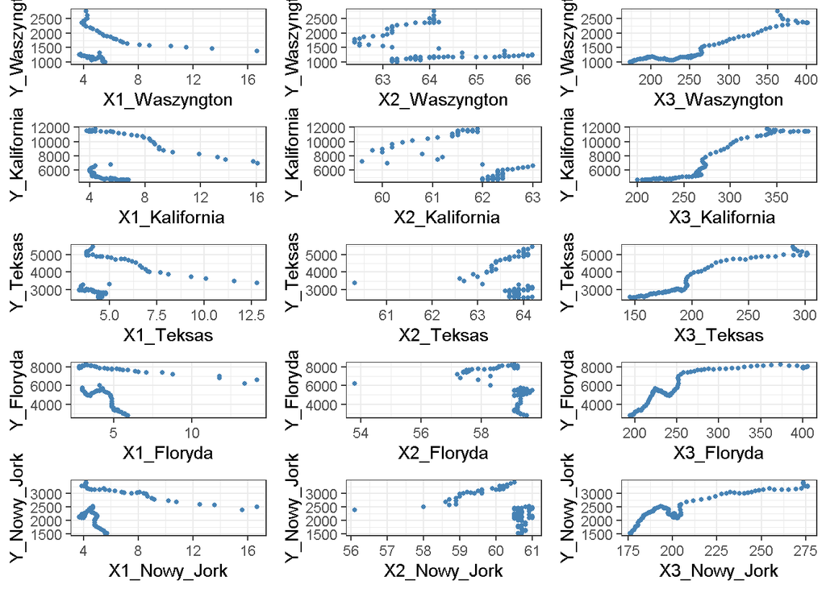

```r
# Wykresy Y=f(X) dla wszystkich przekrojów:
obiekt_lineplot_Y_Waszyngton_funkcja_X1 <- ggplot(df_dane_kolumnowe, aes(X1_Waszyngton, Y_Waszyngton)) + geom_point(size = integer_rozmiar_punktow, color = string_kolor_linii) + theme(text = element_text(size=integer_rozmiar_czcionki)) + theme_bw()
obiekt_lineplot_Y_Waszyngton_funkcja_X2 <- ggplot(df_dane_kolumnowe, aes(X2_Waszyngton, Y_Waszyngton)) + geom_point(size = integer_rozmiar_punktow, color = string_kolor_linii) + theme(text = element_text(size=integer_rozmiar_czcionki)) + theme_bw()
obiekt_lineplot_Y_Waszyngton_funkcja_X3 <- ggplot(df_dane_kolumnowe, aes(X3_Waszyngton, Y_Waszyngton)) + geom_point(size = integer_rozmiar_punktow, color = string_kolor_linii) + theme(text = element_text(size=integer_rozmiar_czcionki)) + theme_bw()

obiekt_lineplot_Y_Kalifornia_funkcja_X1 <- ggplot(df_dane_kolumnowe, aes(X1_Kalifornia, Y_Kalifornia)) + geom_point(size = integer_rozmiar_punktow, color = string_kolor_linii) + theme(text = element_text(size=integer_rozmiar_czcionki)) + theme_bw()
obiekt_lineplot_Y_Kalifornia_funkcja_X2 <- ggplot(df_dane_kolumnowe, aes(X2_Kalifornia, Y_Kalifornia)) + geom_point(size = integer_rozmiar_punktow, color = string_kolor_linii) + theme(text = element_text(size=integer_rozmiar_czcionki)) + theme_bw()
obiekt_lineplot_Y_Kalifornia_funkcja_X3 <- ggplot(df_dane_kolumnowe, aes(X3_Kalifornia, Y_Kalifornia)) + geom_point(size = integer_rozmiar_punktow, color = string_kolor_linii) + theme(text = element_text(size=integer_rozmiar_czcionki)) + theme_bw()

obiekt_lineplot_Y_Teksas_funkcja_X1 <- ggplot(df_dane_kolumnowe, aes(X1_Teksas, Y_Teksas)) + geom_point(size = integer_rozmiar_punktow, color = string_kolor_linii) + theme(text = element_text(size=integer_rozmiar_czcionki)) + theme_bw()
obiekt_lineplot_Y_Teksas_funkcja_X2 <- ggplot(df_dane_kolumnowe, aes(X2_Teksas, Y_Teksas)) + geom_point(size = integer_rozmiar_punktow, color = string_kolor_linii) + theme(text = element_text(size=integer_rozmiar_czcionki)) + theme_bw()
obiekt_lineplot_Y_Teksas_funkcja_X3 <- ggplot(df_dane_kolumnowe, aes(X3_Teksas, Y_Teksas)) + geom_point(size = integer_rozmiar_punktow, color = string_kolor_linii) + theme(text = element_text(size=integer_rozmiar_czcionki)) + theme_bw()

obiekt_lineplot_Y_Floryda_funkcja_X1 <- ggplot(df_dane_kolumnowe, aes(X1_Floryda, Y_Floryda)) + geom_point(size = integer_rozmiar_punktow, color = string_kolor_linii) + theme(text = element_text(size=integer_rozmiar_czcionki)) + theme_bw()
obiekt_lineplot_Y_Floryda_funkcja_X2 <- ggplot(df_dane_kolumnowe, aes(X2_Floryda, Y_Floryda)) + geom_point(size = integer_rozmiar_punktow, color = string_kolor_linii) + theme(text = element_text(size=integer_rozmiar_czcionki)) + theme_bw()
obiekt_lineplot_Y_Floryda_funkcja_X3 <- ggplot(df_dane_kolumnowe, aes(X3_Floryda, Y_Floryda)) + geom_point(size = integer_rozmiar_punktow, color = string_kolor_linii) + theme(text = element_text(size=integer_rozmiar_czcionki)) + theme_bw()

obiekt_lineplot_Y_Nowy_Jork_funkcja_X1 <- ggplot(df_dane_kolumnowe, aes(X1_Nowy_Jork, Y_Nowy_Jork)) + geom_point(size = integer_rozmiar_punktow, color = string_kolor_linii) + theme(text = element_text(size=integer_rozmiar_czcionki)) + theme_bw()
obiekt_lineplot_Y_Nowy_Jork_funkcja_X2 <- ggplot(df_dane_kolumnowe, aes(X2_Nowy_Jork, Y_Nowy_Jork)) + geom_point(size = integer_rozmiar_punktow, color = string_kolor_linii) + theme(text = element_text(size=integer_rozmiar_czcionki)) + theme_bw()
obiekt_lineplot_Y_Nowy_Jork_funkcja_X3 <- ggplot(df_dane_kolumnowe, aes(X3_Nowy_Jork, Y_Nowy_Jork)) + geom_point(size = integer_rozmiar_punktow, color = string_kolor_linii) + theme(text = element_text(size=integer_rozmiar_czcionki)) + theme_bw()

lista_obiektow_lineplot <- list(obiekt_lineplot_Y_Waszyngton_funkcja_X1,
                                obiekt_lineplot_Y_Waszyngton_funkcja_X2,
                                obiekt_lineplot_Y_Waszyngton_funkcja_X3,
                                obiekt_lineplot_Y_Kalifornia_funkcja_X1,
                                obiekt_lineplot_Y_Kalifornia_funkcja_X2,
                                obiekt_lineplot_Y_Kalifornia_funkcja_X3,
                                obiekt_lineplot_Y_Teksas_funkcja_X1,
                                obiekt_lineplot_Y_Teksas_funkcja_X2,
                                obiekt_lineplot_Y_Teksas_funkcja_X3,
                                obiekt_lineplot_Y_Floryda_funkcja_X1,
                                obiekt_lineplot_Y_Floryda_funkcja_X2,
                                obiekt_lineplot_Y_Floryda_funkcja_X3,
                                obiekt_lineplot_Y_Nowy_Jork_funkcja_X1,
                                obiekt_lineplot_Y_Nowy_Jork_funkcja_X2,
                                obiekt_lineplot_Y_Nowy_Jork_funkcja_X3)

grid.arrange(grobs = lista_obiektow_lineplot, ncol = 3, nrow = 5)
```

## 2.7. Efekty ustalone

Poniższe dwa wykresy umożliwiają przeanalizowanie heterogeniczności przekrojów dla zmiennej Y.

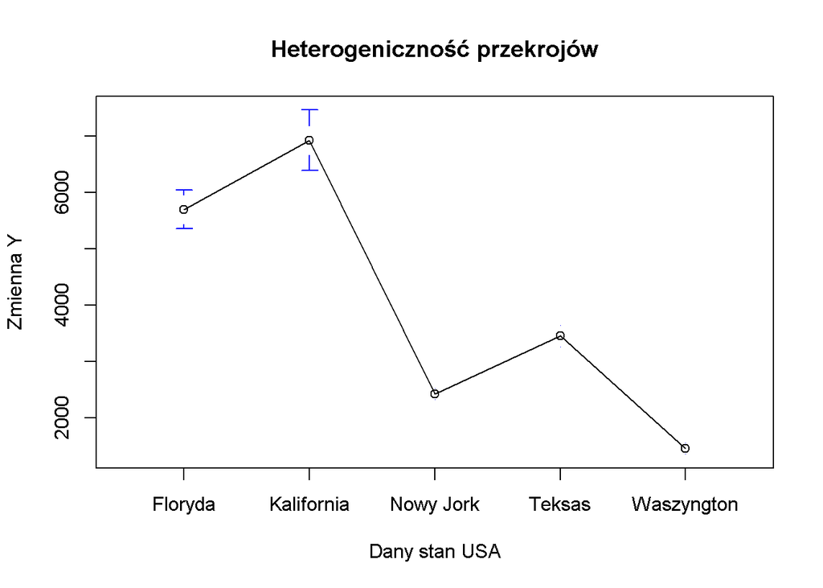

```r
# Efekty ustalone: heterogeniczność przekrojów
plotmeans(Y ~ df_dane_panelowe$State, main="Heterogeniczność przekrojów", data=df_dane_panelowe,
          bars = TRUE,
          connect = TRUE,
          ccol = "black",
          n.label=FALSE,
          xlab = "Dany stan USA",
          ylab = string_podpis_osi_Y)
```

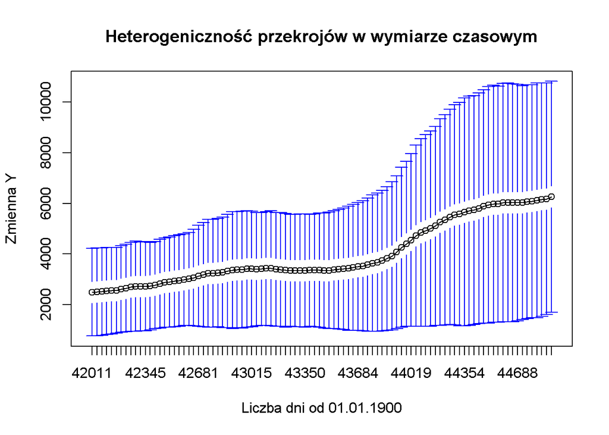

```r
# Efekty ustalone: heterogeniczność w wymiarze czasowym
plotmeans(Y ~ df_dane_panelowe$Full_Date, main="Heterogeniczność przekrojów w wymiarze czasowym", data=df_dane_panelowe,
          xlab = string_podpis_osi_liczba_dni_od_01011900,
          ylab = string_podpis_osi_Y,
          bars = TRUE,
          n.label=FALSE)
```

## 2.8. Podsumowanie sekcji

Każdy z szeregów czasowych wchodzący w skład zbioru analizowanych danych panelowych składa się z 96 próbek (96 miesięcy od stycznia 2015 do grudnia 2022 roku włącznie).

Wykresy porównawcze przedstawione w sekcji 2.2. wskazują, iż roczne liczby zgonów w wyniku przedawkowania opiatów mają charakter wzrostowy we wszystkich pięciu analizowanych stanach USA, choć różni je efekt skali wzrostu (magnituda przyrostu). Widzimy między innymi zbieżność tendencji wzrostowych pomiędzy Teksasem i Waszyngtonem. Tendencje wzrostu liczby zgonów na Florydzie wyraźnie odróżniają się od pozostałych stanów. Widzimy wyraźne różnice w wartościach liczb zgonów pomiędzy pięcioma stanami, co predysponuje te wartości do analizy w formie wielowymiarowej klasyfikacji danych.

# 3. Modele LM, FE, RE

W niniejszej sekcji przeprowadzone zostanie dopasowanie modelu regresji łącznej metodą najmniejszych kwadratów (MNK) i sprawdzenie zasadności tego dopasowania wobec alternatywnych modeli FE i RE.

## 3.1. Trzy zmienne X

W pierwszej kolejności, modelowanie zostanie przeprowadzone dla wszystkich dostępnych zmiennych objaśniających X, czyli X1, X2 oraz X3.

### 3.1.1. Model LM

Modelowanie liniowe (LM) metodą MNK dla trzech zmiennych X daje następujące rezultaty:

```r
model_MNK_na_danych_podstawowych <- lm(Y ~ X1+X2+X3, data=df_dane_panelowe)
summary(model_MNK_na_danych_podstawowych)
```

```
##
## Call:
## lm(formula = Y ~ X1 + X2 + X3, data = df_dane_panelowe)
##
## Residuals:
##     Min      1Q  Median      3Q     Max
## -4469.8 -1308.9   309.4  1236.9  5532.9
##
## Coefficients:
##              Estimate Std. Error t value Pr(>|t|)
## (Intercept) 23353.357   2741.588   8.518   <2e-16 ***
## X1             27.324     40.691   0.672    0.502
## X2           -407.496     42.428  -9.604   <2e-16 ***
## X3             23.496      1.469  15.989   <2e-16 ***
## ---
## Signif. codes:  0 '***' 0.001 '**' 0.01 '*' 0.05 '.' 0.1 ' ' 1
##
## Residual standard error: 1872 on 476 degrees of freedom
## Multiple R-squared:  0.4526, Adjusted R-squared:  0.4491
## F-statistic: 131.2 on 3 and 476 DF,  p-value: < 2.2e-16
```

### 3.1.2. Model FE

Statystyka modelu FE dla trzech zmiennych jest następująca:

```r
model_FE_na_danych_podstawowych <-plm(Y ~ X1+X2+X3, data=df_dane_panelowe,
                                      index=c("State", "Full_Date"), model="within")
summary(model_FE_na_danych_podstawowych)
```

```
## Oneway (individual) effect Within Model
##
## Call:
## plm(formula = Y ~ X1 + X2 + X3, data = df_dane_panelowe, model = "within",
##     index = c("State", "Full_Date"))
##
## Balanced Panel: n = 5, T = 96, N = 480
##
## Residuals:
##      Min.   1st Qu.    Median   3rd Qu.      Max.
## -2065.014  -583.218    48.132   459.249  3397.311
##
## Coefficients:
##      Estimate Std. Error t-value  Pr(>|t|)
## X1   -0.92353   26.95565 -0.0343    0.9727
## X2 -444.00100   76.38775 -5.8125 1.134e-08 ***
## X3   21.51909    0.85707 25.1077 < 2.2e-16 ***
## ---
## Signif. codes:  0 '***' 0.001 '**' 0.01 '*' 0.05 '.' 0.1 ' ' 1
##
## Total Sum of Squares:    1058400000
## Residual Sum of Squares: 388280000
## R-Squared:      0.63313
## Adj. R-Squared: 0.62769
## F-statistic: 271.524 on 3 and 472 DF, p-value: < 2.22e-16
```

### 3.1.3. Model RE

Statystyka modelu RE dla trzech zmiennych jest następująca:

```r
model_RE_na_danych_podstawowych <-plm(Y ~ X1+X2+X3, data=df_dane_panelowe,
                                      index=c("State", "Full_Date"), model="random")
summary(model_RE_na_danych_podstawowych)
```

```
## Oneway (individual) effect Random Effect Model
##    (Swamy-Arora's transformation)
##
## Call:
## plm(formula = Y ~ X1 + X2 + X3, data = df_dane_panelowe, model = "random",
##     index = c("State", "Full_Date"))
##
## Balanced Panel: n = 5, T = 96, N = 480
##
## Effects:
##                    var  std.dev share
## idiosyncratic   822637      907 0.059
## individual    13079225     3616 0.941
## theta: 0.9744
##
## Residuals:
##      Min.   1st Qu.    Median   3rd Qu.      Max.
## -2117.538  -602.786    42.428   424.608  3456.474
##
## Coefficients:
##                Estimate  Std. Error z-value  Pr(>|z|)
## (Intercept) 26209.39562  5100.93058  5.1382 2.774e-07 ***
## X1             -0.83068    26.81781 -0.0310    0.9753
## X2           -443.68182    75.83095 -5.8509 4.888e-09 ***
## X3             21.52172     0.85404 25.1998 < 2.2e-16 ***
## ---
## Signif. codes:  0 '***' 0.001 '**' 0.01 '*' 0.05 '.' 0.1 ' ' 1
##
## Total Sum of Squares:    1059700000
## Residual Sum of Squares: 389130000
## R-Squared:      0.63279
## Adj. R-Squared: 0.63047
## Chisq: 820.254 on 3 DF, p-value: < 2.22e-16
```

### 3.1.4. Podsumowanie modeli

Wartość współczynnika R-kwadrat jest, z dokładnością do trzeciego miejsca po przecinku, taka sama dla obydwu modeli panelowych FE i RE oraz dodatkowo znaczenie przewyższa wartość tego współczynnika dla modelu LM.

We wszystkich trzech modelach, zmienna X1 jest nieistotna statystycznie i z tego powodu zostanie usunięta z dalszego modelowania.

## 3.2. Dwie zmienne X

Modelowanie zostanie powtórzone z pominięciem zmiennej X1, czyli tylko dla zmiennych X2 oraz X3.

### 3.2.1. Model LM

Modelowanie liniowe (LM) metodą MNK dla dwóch zmiennych X daje następujące rezultaty:

```r
model_MNK_bez_X1 <- lm(Y ~ X2+X3, data=df_dane_panelowe)
summary(model_MNK_bez_X1)
```

```
##
## Call:
## lm(formula = Y ~ X2 + X3, data = df_dane_panelowe)
##
## Residuals:
##     Min      1Q  Median      3Q     Max
## -4480.5 -1332.3   248.7  1225.5  5518.2
##
## Coefficients:
##              Estimate Std. Error t value Pr(>|t|)
## (Intercept) 23911.440   2611.080   9.158   <2e-16 ***
## X2           -413.981     41.291 -10.026   <2e-16 ***
## X3             23.432      1.466  15.989   <2e-16 ***
## ---
## Signif. codes:  0 '***' 0.001 '**' 0.01 '*' 0.05 '.' 0.1 ' ' 1
##
## Residual standard error: 1871 on 477 degrees of freedom
## Multiple R-squared:  0.4521, Adjusted R-squared:  0.4498
## F-statistic: 196.8 on 2 and 477 DF,  p-value: < 2.2e-16
```

### 3.2.2. Model jednokierunkowy FE

Statystyka modelu FE dla dwóch zmiennych jest następująca:

```r
model_FE_bez_X1 <-plm(Y ~ X2+X3, data=df_dane_panelowe,
                      index=c("State", "Full_Date"), model="within")
summary(model_FE_bez_X1)
```

```
## Oneway (individual) effect Within Model
##
## Call:
## plm(formula = Y ~ X2 + X3, data = df_dane_panelowe, model = "within",
##     index = c("State", "Full_Date"))
##
## Balanced Panel: n = 5, T = 96, N = 480
##
## Residuals:
##      Min.   1st Qu.    Median   3rd Qu.      Max.
## -2064.984  -582.982    47.231   459.264  3398.149
##
## Coefficients:
##      Estimate Std. Error t-value  Pr(>|t|)
## X2 -442.20964   55.63088  -7.949 1.391e-14 ***
## X3   21.52633    0.82971  25.945 < 2.2e-16 ***
## ---
## Signif. codes:  0 '***' 0.001 '**' 0.01 '*' 0.05 '.' 0.1 ' ' 1
##
## Total Sum of Squares:    1058400000
## Residual Sum of Squares: 388290000
## R-Squared:      0.63313
## Adj. R-Squared: 0.62848
## F-statistic: 408.147 on 2 and 473 DF, p-value: < 2.22e-16
```

### 3.2.3. Model RE

Statystyka modelu RE dla dwóch zmiennych jest następująca:

```r
model_RE_bez_X1 <-plm(Y ~ X2+X3, data=df_dane_panelowe,
                      index=c("State", "Full_Date"), model="random")
summary(model_RE_bez_X1)
```

```
## Oneway (individual) effect Random Effect Model
##    (Swamy-Arora's transformation)
##
## Call:
## plm(formula = Y ~ X2 + X3, data = df_dane_panelowe, model = "random",
##     index = c("State", "Full_Date"))
##
## Balanced Panel: n = 5, T = 96, N = 480
##
## Effects:
##                   var std.dev share
## idiosyncratic  820900     906 0.111
## individual    6579508    2565 0.889
## theta: 0.964
##
## Residuals:
##      Min.   1st Qu.    Median   3rd Qu.      Max.
## -2139.236  -584.547    39.686   421.669  3481.221
##
## Coefficients:
##                Estimate  Std. Error z-value  Pr(>|z|)
## (Intercept) 26096.08067  3633.58959  7.1819 6.875e-13 ***
## X2           -441.94921    55.27460 -7.9955 1.290e-15 ***
## X3             21.53007     0.82775 26.0102 < 2.2e-16 ***
## ---
## Signif. codes:  0 '***' 0.001 '**' 0.01 '*' 0.05 '.' 0.1 ' ' 1
##
## Total Sum of Squares:    1.061e+09
## Residual Sum of Squares: 389960000
## R-Squared:      0.63245
## Adj. R-Squared: 0.63091
## Chisq: 820.779 on 2 DF, p-value: < 2.22e-16
```

### 3.2.4. Podsumowanie modeli

Na podstawie wartości statystyk modeli z usuniętą zmienną X1, widzimy, że w porównaniu do wyników dla modeli z trzema zmiennymi objaśniającymi X, usunięcie tej zmiennej nie skutkowało pogorszeniem wartości współczynników R-kwadrat w modelach FE i RE.

## 3.3. Porównanie LM i FE

Jak widać na podstawie poniższych wyników, jednokierunkowy model FE jest preferowany do opisu danych panelowych w porównaniu do zwykłej regresji liniowej (model LM).

```r
fixef(model_FE_bez_X1)
```

```
##    Floryda Kalifornia  Nowy Jork     Teksas Waszyngton
##      26182      28426      24562      27328      24068
```

```r
summary(fixef(model_FE_bez_X1, type = "dmean"))
```

```
##             Estimate Std. Error t-value Pr(>|t|)
## Floryda       68.466   3318.778  0.0206   0.9835
## Kalifornia  2312.933   3485.585  0.6636   0.5073
## Nowy Jork  -1551.245   3383.586 -0.4585   0.6468
## Teksas      1215.008   3575.941  0.3398   0.7342
## Waszyngton -2045.163   3594.990 -0.5689   0.5697
```

```r
pFtest(model_FE_bez_X1, model_MNK_bez_X1)
```

```
##
##  F test for individual effects
##
## data:  Y ~ X2 + X3
## F = 390.21, df1 = 4, df2 = 473, p-value < 2.2e-16
## alternative hypothesis: significant effects
```

## 3.4. Porównanie FE i RE

```r
phtest(model_FE_bez_X1, model_RE_bez_X1)
```

```
##
##  Hausman Test
##
## data:  Y ~ X2 + X3
## chisq = 0.0050673, df = 2, p-value = 0.9975
## alternative hypothesis: one model is inconsistent
```

## 3.5. Testy regresji FE

W niniejszej sekcji porównany zostanie między innymi jednokierunkowy model FE z dwukierunkowym modelem FE. Obydwa modele zostaną zbudowane dla dwóch zmiennych objaśniających X2 oraz X3.

### 3.5.1. Model jednokierunkowy FE

Statystyka modelu FE dla dwóch zmiennych raz jeszcze:

```r
model_FE_bez_X1 <-plm(Y ~ X2+X3, data=df_dane_panelowe,
                      index=c("State", "Full_Date"), model="within")
summary(model_FE_bez_X1)
```

```
## Oneway (individual) effect Within Model
##
## Call:
## plm(formula = Y ~ X2 + X3, data = df_dane_panelowe, model = "within",
##     index = c("State", "Full_Date"))
##
## Balanced Panel: n = 5, T = 96, N = 480
##
## Residuals:
##      Min.   1st Qu.    Median   3rd Qu.      Max.
## -2064.984  -582.982    47.231   459.264  3398.149
##
## Coefficients:
##      Estimate Std. Error t-value  Pr(>|t|)
## X2 -442.20964   55.63088  -7.949 1.391e-14 ***
## X3   21.52633    0.82971  25.945 < 2.2e-16 ***
## ---
## Signif. codes:  0 '***' 0.001 '**' 0.01 '*' 0.05 '.' 0.1 ' ' 1
##
## Total Sum of Squares:    1058400000
## Residual Sum of Squares: 388290000
## R-Squared:      0.63313
## Adj. R-Squared: 0.62848
## F-statistic: 408.147 on 2 and 473 DF, p-value: < 2.22e-16
```

### 3.5.2. Model dwukierunkowy FE

Statystyka dwukierunkowego modelu FE dla dwóch zmiennych X jest następująca:

```r
model_FE_bez_X1_dwukierunkowy.time <-plm(Y ~ X2+X3+factor(Full_Date),
                                         data=df_dane_panelowe,
                                         index=c("State", "Full_Date"),
                                         model="within")
summary(model_FE_bez_X1_dwukierunkowy.time)
```

```
## Oneway (individual) effect Within Model
##
## Call:
## plm(formula = Y ~ X2 + X3 + factor(Full_Date), data = df_dane_panelowe,
##     model = "within", index = c("State", "Full_Date"))
##
## Balanced Panel: n = 5, T = 96, N = 480
##
## Residuals:
##      Min.   1st Qu.    Median   3rd Qu.      Max.
## -1436.353  -703.862    79.146   510.333  2624.193
##
## Coefficients:
##                         Estimate Std. Error t-value  Pr(>|t|)
## X2                     -314.2408   102.8223 -3.0562 0.0024012 **
## X3                        4.8731     3.2677  1.4913 0.1367157
## factor(Full_Date)42042   -8.5080   603.7849 -0.0141 0.9887647
## factor(Full_Date)42070  -10.4586   603.9002 -0.0173 0.9861917
## factor(Full_Date)42101   -3.0994   604.0050 -0.0051 0.9959084
## factor(Full_Date)42131   17.9144   604.0236  0.0297 0.9763551
## factor(Full_Date)42162    9.7645   604.2089  0.0162 0.9871146
## factor(Full_Date)42192   32.3235   604.5819  0.0535 0.9573903
## factor(Full_Date)42223   52.4666   604.9359  0.0867 0.9309313
## factor(Full_Date)42254   82.9885   605.3185  0.1371 0.8910256
## factor(Full_Date)42284  100.7515   605.6533  0.1664 0.8679690
## factor(Full_Date)42315   98.4352   605.7777  0.1625 0.8710037
## factor(Full_Date)42345  131.4115   605.5347  0.2170 0.8283119
## factor(Full_Date)42376  146.1045   605.6245  0.2412 0.8094953
## factor(Full_Date)42407  194.9291   605.8177  0.3218 0.7478109
## factor(Full_Date)42436  238.6521   606.2028  0.3937 0.6940366
## factor(Full_Date)42467  280.0740   606.4599  0.4618 0.6444776
## factor(Full_Date)42497  298.1304   606.5968  0.4915 0.6233720
## factor(Full_Date)42528  321.9725   606.9986  0.5304 0.5961228
## factor(Full_Date)42558  348.3627   607.2804  0.5736 0.5665499
## factor(Full_Date)42589  376.7584   607.7687  0.6199 0.5356943
## factor(Full_Date)42620  401.2703   608.1367  0.6598 0.5097610
## factor(Full_Date)42650  431.9916   608.8468  0.7095 0.4784367
## factor(Full_Date)42681  493.3693   609.4137  0.8096 0.4186908
## factor(Full_Date)42711  538.1424   610.1643  0.8820 0.3783572
## factor(Full_Date)42742  576.6177   610.8289  0.9440 0.3457766
```

[output cut: 64 more lines]

```
## factor(Full_Date)44719 2673.7416   827.8226  3.2298 0.0013470 **
## factor(Full_Date)44749 2706.6185   821.6981  3.2939 0.0010812 **
## factor(Full_Date)44780 2723.1082   811.0348  3.3576 0.0008662 ***
## factor(Full_Date)44811 2793.8042   800.6724  3.4893 0.0005413 ***
## factor(Full_Date)44841 2837.4439   797.0511  3.5599 0.0004183 ***
## factor(Full_Date)44872 2895.8318   792.6380  3.6534 0.0002953 ***
## factor(Full_Date)44902 3009.2737   788.2285  3.8178 0.0001573 ***
## ---
## Signif. codes:  0 '***' 0.001 '**' 0.01 '*' 0.05 '.' 0.1 ' ' 1
##
## Total Sum of Squares:    1058400000
## Residual Sum of Squares: 344460000
## R-Squared:      0.67454
## Adj. R-Squared: 0.58758
## F-statistic: 8.07681 on 97 and 378 DF, p-value: < 2.22e-16
```

### 3.5.3. Model FE - Test Hausmana

```r
pFtest(model_FE_bez_X1_dwukierunkowy.time, model_FE_bez_X1)
```

```
##
##  F test for individual effects
##
## data:  Y ~ X2 + X3 + factor(Full_Date)
## F = 0.5063, df1 = 95, df2 = 378, p-value = 0.9999
## alternative hypothesis: significant effects
```

Wyniki testu wskazują, że jednokierunkowy model FE jest preferowany w stosunku do dwukierunkowego modelu FE.

### 3.5.4. Model FE - Test BP

Istotność statystyczna efektów losowych w dwukierunkowym modelu FE zostanie przebadana przy użyciu testu Breuscha-Pagana (BP), którego hipoteza zerowa mówi, iż efekty losowe są nieistotne. Statystyka testu jest następująca:

```r
plmtest(model_FE_bez_X1, c("time"), type=("bp"))
```

```
##
##  Lagrange Multiplier Test - time effects (Breusch-Pagan)
##
## data:  Y ~ X2 + X3
## chisq = 53.444, df = 1, p-value = 2.661e-13
## alternative hypothesis: significant effects
```

Na podstawie testu widzimy, iż czynnik czasowy jest statystycznie istotny w modelu jednokierunkowym.

### 3.5.5 Podsumowanie testów FE

Jednokierunkowy model FE jest preferowany w stosunku do dwukierunkowego modelu FE.

## 3.6. Testy regresji RE

### 3.6.1. Model RE

Regresja łączna RE ma następującą postać:

```r
model_RE_pooling_bez_X1 <-plm(Y ~ X2+X3, data=df_dane_panelowe,
                              index=c("State", "Full_Date"), model="pooling")
summary(model_RE_pooling_bez_X1)
```

```
## Pooling Model
##
## Call:
## plm(formula = Y ~ X2 + X3, data = df_dane_panelowe, model = "pooling",
##     index = c("State", "Full_Date"))
##
## Balanced Panel: n = 5, T = 96, N = 480
##
## Residuals:
##     Min.  1st Qu.   Median  3rd Qu.     Max.
## -4480.46 -1332.28   248.69  1225.47  5518.22
##
## Coefficients:
##               Estimate Std. Error  t-value  Pr(>|t|)
## (Intercept) 23911.4397  2611.0796   9.1577 < 2.2e-16 ***
## X2           -413.9806    41.2910 -10.0259 < 2.2e-16 ***
## X3             23.4320     1.4655  15.9888 < 2.2e-16 ***
## ---
## Signif. codes:  0 '***' 0.001 '**' 0.01 '*' 0.05 '.' 0.1 ' ' 1
##
## Total Sum of Squares:    3.047e+09
## Residual Sum of Squares: 1669600000
## R-Squared:      0.45205
## Adj. R-Squared: 0.44976
## F-statistic: 196.762 on 2 and 477 DF, p-value: < 2.22e-16
```

### 3.6.2. Model RE - Test BP

Istotność statystyczna efektów losowych w modelu RE zostanie przebadana przy użyciu testu Breuscha-Pagana. Statystyka testu jest następująca:

```r
plmtest(model_RE_pooling_bez_X1, type=c("bp"))
```

```
##
##  Lagrange Multiplier Test - (Breusch-Pagan)
##
## data:  Y ~ X2 + X3
## chisq = 13251, df = 1, p-value < 2.2e-16
## alternative hypothesis: significant effects
```

### 3.6.3. Model RE - Test Hausmana

```r
pFtest(model_FE_bez_X1, model_RE_pooling_bez_X1)
```

```
##
##  F test for individual effects
##
## data:  Y ~ X2 + X3
## F = 390.21, df1 = 4, df2 = 473, p-value < 2.2e-16
## alternative hypothesis: significant effects
```

W teście uzyskano wartość p < 0,001, a co za tym idzie odrzucam hipotezę zerową testu na rzecz hipotezy alternatywnej, która mówi, iż w modelu istnieją statystycznie istotne efekty ustalone. Tym samym, jednokierunkowy model FE jest preferowany w stosunku do regresji łącznej (model RE).

### 3.6.4 Podsumowanie testów RE

Podsumowując, przeprowadzone testy selekcyjne wskazują na wybór jednokierunkowego modelu FE.

## 3.7. Podsumowanie sekcji

Jednokierunkowy model FE zostaje skierowany do dalszej analizy. Przetestowane zostaną heteroskedastyczność i autokorelacja tego modelu.

# 4. Testy modelu FE

W niniejszej sekcji, jednokierunkowy model FE zostanie przetestowany pod kątem występowania w nim heteroskedastyczności oraz autokorelacji.

## 4.1. Autokorelacja

Przy użyciu testu Breuscha-Godfrey’a/Wooldrige’a przetestowano autokorelację wewnątrzgrupową 1. rzędu. Hipoteza zerowa wyżej wymienionego testu mówi, iż nie występuje korelacja do danego rzędu włącznie. Statystyka testu jest następująca:

```r
pbgtest(model_FE_bez_X1, order=1)
```

```
##
##  Breusch-Godfrey/Wooldridge test for serial correlation in panel models
##
## data:  Y ~ X2 + X3
## chisq = 436.38, df = 1, p-value < 2.2e-16
## alternative hypothesis: serial correlation in idiosyncratic errors
```

Wyniki testu wskazują, iż są podstawy do odrzucenia hipotezy zerowej. Innymi słowy, istnieją podstawy do stwierdzenia, iż autokorelacja występuje w jednokierunkowym modelu FE.

## 4.2. Heteroskedastyczność

Ewentualne występowanie heteroskedastyczności w jednokierunkowym modelu FE zostanie przetestowane przy użyciu testu Breuscha-Pagana w dwóch wariantach. Hipoteza zerowa obydwu tych testów mówi, iż w modelu występuje homoskedastyczność (brak jest heteroskedastyczności). Statystyka testu jest następująca:

```r
bptest(Y ~ X2+X3, data=df_dane_panelowe,  studentize=T)
```

```
##
##  studentized Breusch-Pagan test
##
## data:  Y ~ X2 + X3
## BP = 198.77, df = 2, p-value < 2.2e-16
```

```r
bptest(Y ~ X2+X3, data=df_dane_panelowe,  studentize=F)
```

```
##
##  Breusch-Pagan test
##
## data:  Y ~ X2 + X3
## BP = 222.83, df = 2, p-value < 2.2e-16
```

Obydwa warianty testu sugerują występowanie heteroskedastyczności w jednokierunkowym modelu FE.

## 4.3. Podsumowanie sekcji

W modelu stwierdzono istotnie statystyczne autokorelację oraz heteroskedastyczność.

# 5. Korekta modelu FE

Ze względu na wykrycie w modelu istotnych statystycznie autokorelacji oraz heteroskedastyczności, decydujemy się na zastosowanie dwóch wariantów korekty.

Korekty zostaną zrealizowane przy pomocy zewnętrznej biblioteki `panelAR’, [17].

Pakiet ten umożliwia:

- tylko korektę autokorelacji,
- jednoczesną korektę autokorelacji oraz heteroskedastyczności.

## 5.1. Tylko autokorelacja

Przy użyciu pakietu `panelAR’ w modelu zostanie skorygowana tylko autokorelacja. Dodatkowo przeprowadzony zostanie test Hausmana.

```r
model_tylko_z_korekta_autokorelacji <- panelAR(Y ~ X2+X3,
                                      data=df_dane_panelowe,
                                      panelVar='State',
                                      timeVar='Full_Date',
                                      autoCorr='psar1',
                                      panelCorrMethod='none',
                                      rhotype = "theil")
summary(model_tylko_z_korekta_autokorelacji)
```

```
##
## Panel Regression with AR(1) Prais-Winsten correction and homoskedastic variance
##
## Balanced Panel Design:
##  Total obs.:       480 Avg obs. per panel 96
##  Number of panels: 5   Max obs. per panel 96
##  Number of times:  96  Min obs. per panel 96
##
## Coefficients:
##             Estimate Std. Error t value Pr(>|t|)
## (Intercept) 2168.273    938.496   2.310  0.02129 *
## X2           -41.412     14.554  -2.845  0.00463 **
## X3            21.161      1.153  18.359  < 2e-16 ***
## ---
## Signif. codes:  0 '***' 0.001 '**' 0.01 '*' 0.05 '.' 0.1 ' ' 1
##
## R-squared: 0.7241
## Wald statistic: 348.6252, Pr(>Chisq(2)): 0
```

```r
roznice_wspolczynnikow <-
  model_tylko_z_korekta_autokorelacji$coefficients - model_RE_bez_X1$coefficients
roznice_V <-
  model_tylko_z_korekta_autokorelacji$vcov-model_RE_bez_X1$vcov

nowa_statystyka_hausmana <-
  abs(t(roznice_wspolczynnikow)%*%solve(roznice_V)%*%roznice_wspolczynnikow)
nowa_statystyka_hausmana
```

```
##         [,1]
## [1,] 54.4122
```

```r
nowa_p_wartosc <- 1-pchisq(abs(nowa_statystyka_hausmana), 2)
nowa_p_wartosc
```

```
##              [,1]
## [1,] 1.529443e-12
```

## 5.2. Podwójna korekta

W niniejszej podsekcji przeprowadzona zostanie jednoczesna korekta autokorelacji oraz heteroskedastyczności. Podobnie jak wcześniej, po korektach przeprowadzony zostanie również test Hausmana.

```r
model_z_korekta_autokorelacji_i_heteroskedastycznosci <- panelAR(Y ~ X2+X3,
                                                                 data=df_dane_panelowe,
                                                                 panelVar='State',
                                                                 timeVar='Full_Date',
                                                                 autoCorr='psar1',
                                                                 panelCorrMethod='pcse',
                                                                 rhotype = "theil")
summary(model_z_korekta_autokorelacji_i_heteroskedastycznosci)
```

```
##
## Panel Regression with AR(1) Prais-Winsten correction and panel-corrected standard errors
##
## Balanced Panel Design:
##  Total obs.:       480 Avg obs. per panel 96
##  Number of panels: 5   Max obs. per panel 96
##  Number of times:  96  Min obs. per panel 96
##
## Coefficients:
##             Estimate Std. Error t value Pr(>|t|)
## (Intercept) 2168.273    973.801   2.227  0.02644 *
## X2           -41.412     14.905  -2.778  0.00568 **
## X3            21.161      1.255  16.856  < 2e-16 ***
## ---
## Signif. codes:  0 '***' 0.001 '**' 0.01 '*' 0.05 '.' 0.1 ' ' 1
##
## R-squared: 0.7241
## Wald statistic: 295.4863, Pr(>Chisq(2)): 0
```

```r
roznice_wspolczynnikow <-
  model_z_korekta_autokorelacji_i_heteroskedastycznosci$coefficients-model_RE_bez_X1$coefficients
roznice_V <-
  model_z_korekta_autokorelacji_i_heteroskedastycznosci$vcov-model_RE_bez_X1$vcov

nowa_statystyka_hausmana <-
  abs(t(roznice_wspolczynnikow)%*%solve(roznice_V)%*%roznice_wspolczynnikow)
nowa_statystyka_hausmana
```

```
##          [,1]
## [1,] 55.33374
```

```r
nowa_p_wartosc <- 1-pchisq(abs(nowa_statystyka_hausmana), 2)
nowa_p_wartosc
```

```
##              [,1]
## [1,] 9.647838e-13
```

## 5.3. Podsumowanie sekcji

Bez względu na wybrany schemat korekty, najlepszym z modeli jest jednokierunkowy model FE z dwoma istotnymi zmiennymi X. Do ostatecznej interpretacji powinniśmy wybrać współczynniki skorygowanego modelu FE, ponieważ tego typu model:

- ma skorygowaną autokorelację oraz heteroskedastyczność, które występują w podstawowym modelu FE,
- jest właściwszy do testu Hausmana.

# 6. Podsumowanie

Ostateczna interpretacja jednokierunkowego modelu FE jest następująca:

- wzrost wartości zmiennej X2 o jednostkę powoduje spadek wartości zmiennej Y o -41,412,
- wzrost wartości zmiennej X3 o jednostkę powoduje wzrost wartości zmiennej Y o +21,161.

Dopasowanie modelu jest na akceptowalnym poziomie i jego wartość wynosi R-kwadrat = 72,41%. Ogólnie, modelowanie należy uznać za bardziej udane, niż to w projekcie Analizy Współzależności Zjawisk.

```r
summary(model_z_korekta_autokorelacji_i_heteroskedastycznosci)
```

```
##
## Panel Regression with AR(1) Prais-Winsten correction and panel-corrected standard errors
##
## Balanced Panel Design:
##  Total obs.:       480 Avg obs. per panel 96
##  Number of panels: 5   Max obs. per panel 96
##  Number of times:  96  Min obs. per panel 96
##
## Coefficients:
##             Estimate Std. Error t value Pr(>|t|)
## (Intercept) 2168.273    973.801   2.227  0.02644 *
## X2           -41.412     14.905  -2.778  0.00568 **
## X3            21.161      1.255  16.856  < 2e-16 ***
## ---
## Signif. codes:  0 '***' 0.001 '**' 0.01 '*' 0.05 '.' 0.1 ' ' 1
##
## R-squared: 0.7241
## Wald statistic: 295.4863, Pr(>Chisq(2)): 0
```

# 7. Literatura

[1] - https://data.cdc.gov/NCHS/VSRR-Provisional-Drug-Overdose-Death-Counts/xkb8-kh2a/about_data

[2] - https://fred.stlouisfed.org/series/WAUR

[3] - https://fred.stlouisfed.org/series/LBSSA53

[4] - https://fred.stlouisfed.org/series/SEXRSA

[5] - https://fred.stlouisfed.org/series/CAUR

[6] - https://fred.stlouisfed.org/series/LBSSA06

[7] - https://fred.stlouisfed.org/series/SFXRSA

[8] - https://fred.stlouisfed.org/series/TXUR

[9] - https://fred.stlouisfed.org/series/LBSSA48

[10] - https://fred.stlouisfed.org/series/DAXRSA

[11] - https://fred.stlouisfed.org/series/FLUR

[12] - https://fred.stlouisfed.org/series/LBSSA12

[13] - https://fred.stlouisfed.org/series/MIXRSA

[14] - https://fred.stlouisfed.org/series/NYUR

[15] - https://fred.stlouisfed.org/series/LBSSA36

[16] - https://fred.stlouisfed.org/series/NYXRSA

[17] - https://github.com/kkashin/panelAR